**Predicting Concrete Strength - Regression Problem**

[figure not shown]

# Introduction

## About Dataset

The dataset was generated from a deep learning model trained on the Concrete Strength Prediction dataset.

# Import Libraries & Read Dataset

```python
import pandas as pd
import numpy as np
import matplotlib.pyplot as plt
import seaborn as sns

from sklearn.feature_selection import RFE
from sklearn.ensemble import RandomForestRegressor, BaggingRegressor, AdaBoostRegressor
from sklearn.tree import DecisionTreeRegressor
from sklearn.linear_model import Lasso, LassoCV, LinearRegression,SGDRegressor, Ridge
import xgboost as xgb
from sklearn.preprocessing import StandardScaler
from sklearn.svm import SVR, LinearSVR
from sklearn.ensemble import VotingRegressor, GradientBoostingRegressor
from sklearn.model_selection import cross_val_score, KFold, GridSearchCV, RandomizedSearchCV
```

```python
train = pd.read_csv('data/train.csv',index_col = 'id')
test = pd.read_csv('data/test.csv',index_col = 'id')
```

# Preview files

```python
train.head()
```

| id | CementComponent | BlastFurnaceSlag | FlyAshComponent | WaterComponent | SuperplasticizerComponent | CoarseAggregateComponent | FineAggregateComponent | AgeInDays | Strength |
| --- | --- | --- | --- | --- | --- | --- | --- | --- | --- |
| 0 | 525.0 | 0.0 | 0.0 | 186.0 | 0.0 | 1125.0 | 613.0 | 3 | 10.38 |
| 1 | 143.0 | 169.0 | 143.0 | 191.0 | 8.0 | 967.0 | 643.0 | 28 | 23.52 |
| 2 | 289.0 | 134.7 | 0.0 | 185.7 | 0.0 | 1075.0 | 795.3 | 28 | 36.96 |
| 3 | 304.0 | 76.0 | 0.0 | 228.0 | 0.0 | 932.0 | 670.0 | 365 | 39.05 |
| 4 | 157.0 | 236.0 | 0.0 | 192.0 | 0.0 | 935.4 | 781.2 | 90 | 74.19 |

```python
y = train['Strength']
train.drop('Strength',axis=1, inplace = True)
y
```

```
id
0       10.38
1       23.52
2       36.96
3       39.05
4       74.19
        ...
5402    15.42
5403    49.20
5404    39.30
5405    39.61
5406    63.14
Name: Strength, Length: 5407, dtype: float64
```

```python
train.shape
```

```
(5407, 8)
```

```python
train.info()
```

```
<class 'pandas.core.frame.DataFrame'>
Int64Index: 5407 entries, 0 to 5406
Data columns (total 8 columns):
 #   Column                     Non-Null Count  Dtype
---  ------                     --------------  -----
 0   CementComponent            5407 non-null   float64
 1   BlastFurnaceSlag           5407 non-null   float64
 2   FlyAshComponent            5407 non-null   float64
 3   WaterComponent             5407 non-null   float64
 4   SuperplasticizerComponent  5407 non-null   float64
 5   CoarseAggregateComponent   5407 non-null   float64
 6   FineAggregateComponent     5407 non-null   float64
 7   AgeInDays                  5407 non-null   int64
dtypes: float64(7), int64(1)
memory usage: 380.2 KB
```

# Preprocessing of Data

## Checking for correlation of variables

The pairplot shows the relationship between the variables in the dataset. There doesn't seem to be any strong correlation between variables, which is good for models.

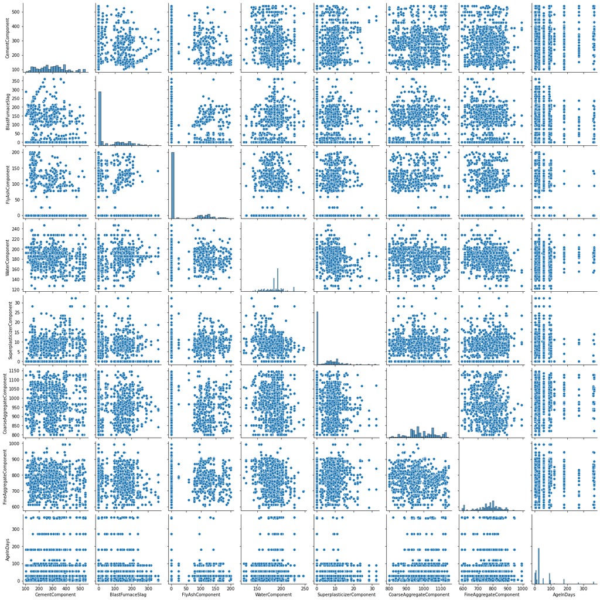

```python
sns.pairplot(train)
plt.show()
```

## Missing values

The dataset has no missing values in both the train and test sets.

```python
train.isna().sum()
```

```
CementComponent              0
BlastFurnaceSlag             0
FlyAshComponent              0
WaterComponent               0
SuperplasticizerComponent    0
CoarseAggregateComponent     0
FineAggregateComponent       0
AgeInDays                    0
dtype: int64
```

```python
test.isna().sum()
```

```
CementComponent              0
BlastFurnaceSlag             0
FlyAshComponent              0
WaterComponent               0
SuperplasticizerComponent    0
CoarseAggregateComponent     0
FineAggregateComponent       0
AgeInDays                    0
dtype: int64
```

## Outliers

The boxplot highlights two key points:

- There are outliers in the dataset, and these could create bias in our models. These will be removed.
- The variables have different variances, and will therefore require standardization before modeling.

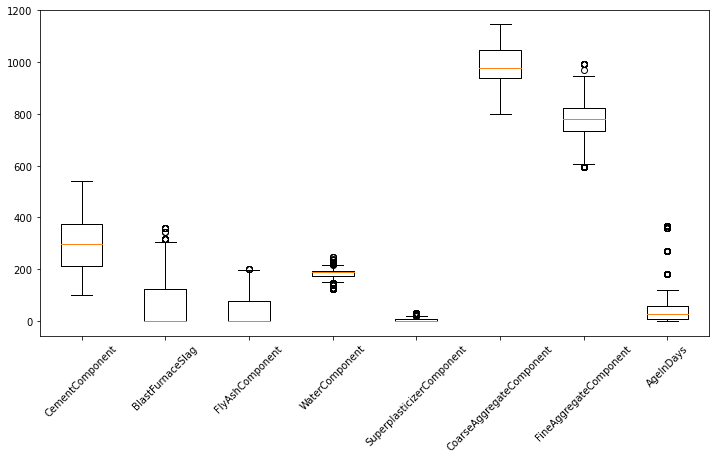

```python
fig = plt.figure(figsize = (12,6))
plt.boxplot(train)
plt.xticks([1,2,3,4,5,6,7,8],train.columns, rotation = 45)
plt.show()
```

### Removing outliers using standard deviation method

This method eliminates all data points further than 3 standard deviations from the mean.

```python
for col in train.columns:
    mean = train[col].mean()
    std = train[col].std()
    cut_off = std * 3

    # Set the limits
    upper_limit = mean + cut_off
    lower_limit = mean - cut_off

    # Replace outliers with nan values
    train.loc[(train[col] > upper_limit) | (train[col] < lower_limit),[col]] = np.nan
```

```python
train.isna().sum()
```

```
CementComponent                0
BlastFurnaceSlag              21
FlyAshComponent                5
WaterComponent                37
SuperplasticizerComponent     72
CoarseAggregateComponent       0
FineAggregateComponent         0
AgeInDays                    203
dtype: int64
```

```python
print(train.shape)
train.dropna(how = 'any', inplace =True)
y = y.loc[train.index]
print(train.shape)
```

```
(5407, 8)
(5084, 8)
```

## Standardization of data

```python
scaler = StandardScaler()
```

```python
# Fit and transform the training set
train[train.columns] = scaler.fit_transform(train)

# Transform the test set
test[train.columns] = scaler.transform(test)
```

# Feature selection

We will evaluate whether dropping features reduces noise and improves our model.

## Feature selection with random forests

```python
for i in [8,7,6,5,4,3,2,1]:
    rfe_rf = RFE(estimator = RandomForestRegressor(), n_features_to_select = i)
    rfe_rf.fit(train, y)
    kf = KFold(n_splits = 6, shuffle = True, random_state = 90)
    scores = cross_val_score(rfe_rf, train, y, cv = kf, scoring = 'neg_mean_squared_error')
    print(f'{i} features = {np.mean(np.sqrt(np.abs(scores)))} RMSE')
```

```
8 features = 12.813488174653935 RMSE
7 features = 12.795813003556447 RMSE
6 features = 12.866035663336426 RMSE
5 features = 12.929760464571054 RMSE
4 features = 13.135066320406521 RMSE
3 features = 13.165201172194164 RMSE
2 features = 13.012243437834194 RMSE
1 features = 12.772605103094792 RMSE
```

## Feature selection with xgboost

```python
for i in [8,7,6,5,4,3,2,1]:
    rfe_xgb = RFE(estimator = xgb.XGBRegressor(), n_features_to_select = i)
    rfe_xgb.fit(train, y)
    kf = KFold(n_splits = 6, shuffle = True, random_state = 90)
    scores = cross_val_score(rfe_xgb, train, y, cv = kf, scoring = 'neg_mean_squared_error')
    print(f'{i} features = {np.mean(np.sqrt(np.abs(scores)))} RMSE')
```

```
8 features = 12.899194920064547 RMSE
7 features = 12.886060861673071 RMSE
6 features = 12.848598318330184 RMSE
5 features = 13.001480301990059 RMSE
4 features = 12.947112116963737 RMSE
3 features = 13.00364180132494 RMSE
2 features = 12.729717681916922 RMSE
1 features = 12.771778480800249 RMSE
```

## Feature selection with Lasso

Lasso does not show promising results in feature selection and reduction in RMSE.

```python
for i in [8,7,6,5,4,3,2,1]:
    rfe_las = RFE(estimator = Lasso(alpha =0.00548), n_features_to_select = i)
    rfe_las.fit(train, y)
    kf = KFold(n_splits = 6, shuffle = True, random_state = 90)
    scores = cross_val_score(rfe_las, train, y, cv = kf, scoring = 'neg_mean_squared_error')
    print(f'{i} features = {np.mean(np.sqrt(np.abs(scores)))} RMSE')
```

```
8 features = 14.036035123106002 RMSE
7 features = 14.039294499092676 RMSE
6 features = 14.038724029673533 RMSE
5 features = 14.03803071621177 RMSE
4 features = 14.059571023171335 RMSE
3 features = 14.172956495699166 RMSE
2 features = 14.32283385873672 RMSE
1 features = 14.96513638480291 RMSE
```

# Model evaluation

We evaluate different models and select the best five for hyperparameter tuning.

```python
estimators = [('bagging',BaggingRegressor()), ('adaboost',AdaBoostRegressor()),('decision_tree',DecisionTreeRegressor()),('linear',LinearRegression()),
              ('svr',SVR()),('randomforest',RandomForestRegressor()),('xgboost',xgb.XGBRegressor()),('lasso',Lasso()),('sgd',SGDRegressor()),('ridge',Ridge()),
             ('svr_l',LinearSVR()),('gradientb',GradientBoostingRegressor())]
rmse_list =[]
for clf_name, clf in estimators:
    clf.fit(train, y)
    kf = KFold(n_splits = 6, shuffle = True, random_state = 90)
    scores = cross_val_score(clf, train, y, cv = kf, scoring = 'neg_mean_squared_error')
    rmse = np.mean(np.sqrt(np.abs(scores)))
    rmse_list.append({'rmse':rmse, 'regressor':clf_name})
```

```python
rmse_df = pd.DataFrame(rmse_list).set_index('regressor')
rmse_df.sort_values(by='rmse')
```

| regressor | rmse |
| --- | --- |
| gradientb | 12.110868 |
| adaboost | 12.679252 |
| randomforest | 12.821881 |
| xgboost | 12.899195 |
| svr | 12.976938 |
| bagging | 13.096342 |
| ridge | 14.036038 |
| linear | 14.036051 |
| sgd | 14.052556 |
| svr_l | 14.123996 |
| lasso | 14.241140 |
| decision_tree | 15.267847 |

## Voting

```python
estimators = [('svr',SVR()),('xgboost',xgb.XGBRegressor()),('randomforest',RandomForestRegressor()),
              ('adaboost',AdaBoostRegressor()),('gradientb',GradientBoostingRegressor())]
vr = VotingRegressor(estimators = estimators)
vr.fit(train,y)
kf = KFold(n_splits = 6, shuffle = True, random_state = 90)
scores = cross_val_score(vr, train, y, cv = kf, scoring = 'neg_mean_squared_error')
rmse = np.mean(np.sqrt(np.abs(scores)))
print(f'{rmse:,.4f}')
```

```
12.1512
```

## Hyperparameter Tuning

### xgboost

```python
# Instantiate model
xgb_reg = xgb.XGBRegressor()

# Instantiate a KFold object
kf = KFold(n_splits =6, shuffle = True, random_state = 90)

# Create your parameters
param_grid = {
    'n_estimators':[12], 'max_depth':[3],'learning_rate':[0.35],'reg_alpha':[10],'reg_lambda':[7]
}
# Perform cross validation
xgb_cv = GridSearchCV(estimator = xgb_reg, param_grid = param_grid, cv = kf, scoring = 'neg_mean_squared_error', verbose =1)

# Fit model
xgb_cv.fit(train,y)

# Evaluate model
rmse = np.sqrt(np.abs(xgb_cv.best_score_))
print(f'Best score {rmse:,.4}')
print(f'Best params {xgb_cv.best_params_}')
```

```
Fitting 6 folds for each of 1 candidates, totalling 6 fits
Best score 12.1
Best params {'learning_rate': 0.35, 'max_depth': 3, 'n_estimators': 12, 'reg_alpha': 10, 'reg_lambda': 7}
```

```python
xgb_reg = xgb_cv.best_estimator_
```

### Support Vector Regressor

```python
# Instantiate model
svr = SVR()

# Instantiate a KFold object
kf = KFold(n_splits =6, shuffle = True, random_state = 90)

# Create your parameters
param_grid = {
    'gamma':[0.2], 'C':[10], 'epsilon':[5]
}
# Perform cross validation
svr_cv = GridSearchCV(estimator = svr, param_grid = param_grid, cv = kf, scoring = 'neg_mean_squared_error', verbose =1)

# Fit model
svr_cv.fit(train,y)

# Evaluate model
rmse = np.sqrt(np.abs(svr_cv.best_score_))
print(f'Best score {rmse:,.4}')
print(f'Best params {svr_cv.best_params_}')
```

```
Fitting 6 folds for each of 1 candidates, totalling 6 fits
Best score 12.4
Best params {'C': 10, 'epsilon': 5, 'gamma': 0.2}
```

```python
svr_reg = svr_cv.best_estimator_
```

### Random Forest

```python
# Instantiate model
random_f = RandomForestRegressor()

# Instantiate a KFold object
kf = KFold(n_splits =6, shuffle = True, random_state = 90)

# Create your parameters
param_grid = {
    'n_estimators':[200], 'max_depth':[6], 'min_samples_leaf':[7]
}
# Perform cross validation
random_f_cv = GridSearchCV(estimator = random_f, param_grid = param_grid, cv = kf, scoring = 'neg_mean_squared_error', verbose =1)

# Fit model
random_f_cv.fit(train,y)

# Evaluate model
rmse = np.sqrt(np.abs(random_f_cv.best_score_))
print(f'Best score {rmse:,.4}')
print(f'Best params {random_f_cv.best_params_}')
```

```
Fitting 6 folds for each of 1 candidates, totalling 6 fits
Best score 12.15
Best params {'max_depth': 6, 'min_samples_leaf': 7, 'n_estimators': 200}
```

```python
r_forest_reg = random_f_cv.best_estimator_
```

### Gradient Boosting

```python
# Instantiate model
gradient = GradientBoostingRegressor(random_state=90)

# Instantiate a KFold object
kf = KFold(n_splits =6, shuffle = True, random_state = 90)

# Create your parameters
param_grid = {
    'max_depth':[2], 'n_estimators':[110,115,120,125]
}
# Perform cross validation
gradient_cv = GridSearchCV(estimator = gradient, param_grid = param_grid, cv = kf, scoring = 'neg_mean_squared_error', verbose =1)

# Fit model
gradient_cv.fit(train,y)

# Evaluate model
rmse = np.sqrt(np.abs(gradient_cv.best_score_))
print(f'Best score {rmse:,.4}')
print(f'Best params {gradient_cv.best_params_}')
```

```
Fitting 6 folds for each of 4 candidates, totalling 24 fits
Best score 12.1
Best params {'max_depth': 2, 'n_estimators': 120}
```

```python
gradient_reg = gradient_cv.best_estimator_
```

### Adaboost

```python
# Instantiate model
ada = AdaBoostRegressor()

# Instantiate a KFold object
kf = KFold(n_splits =6, shuffle = True, random_state = 90)

# Create your parameters
param_grid = {
    'learning_rate':[0.01,0.1]
}
# Perform cross validation
ada_cv = GridSearchCV(estimator = gradient_reg, param_grid = param_grid, cv = kf, scoring = 'neg_mean_squared_error', verbose =1)

# Fit model
ada_cv.fit(train,y)

# Evaluate model
rmse = np.sqrt(np.abs(ada_cv.best_score_))
print(f'Best score {rmse:,.4}')
print(f'Best params {ada_cv.best_params_}')
```

```
Fitting 6 folds for each of 2 candidates, totalling 12 fits
Best score 12.1
Best params {'learning_rate': 0.1}
```

```python
ada_reg = AdaBoostRegressor(base_estimator = gradient_reg, learning_rate = 0.1)
```

### Bagging Regressor

```python
# Instantiate model
bag = BaggingRegressor()

# Instantiate a KFold object
kf = KFold(n_splits =6, shuffle = True, random_state = 90)

# Create your parameters
param_grid = {
    'max_samples':[0.18], 'n_estimators':[150]
}
# Perform cross validation
bag_cv = GridSearchCV(estimator = bag, param_grid = param_grid, cv = kf, scoring = 'neg_mean_squared_error')

# Fit model
bag_cv.fit(train,y)

# Evaluate model
rmse = np.sqrt(np.abs(bag_cv.best_score_))
print(f'Best score {rmse:,.4}')
print(f'Best params {bag_cv.best_params_}')
```

```
Best score 12.21
Best params {'max_samples': 0.18, 'n_estimators': 150}
```

```python
bag_reg = bag_cv.best_estimator_
```

## Evaluating the meta model

### Testing individual models

```python
estimators = [('svr',svr_reg),('xgboost',xgb_reg),('randomforest',r_forest_reg), ('adaboost',ada_reg),('bagging',bag_reg),('gradient',gradient_reg)]
rmse_ls =[]
for clf_name, clf in estimators:
    clf.fit(train, y)
    kf = KFold(n_splits = 6, shuffle = True, random_state = 90)
    scores = cross_val_score(clf, train, y, cv = kf, scoring = 'neg_mean_squared_error')
    rmse = np.mean(np.sqrt(np.abs(scores)))
    print(f'{rmse:,.4f} for {clf_name}')
    rmse_ls.append({'rmse':rmse, 'regressor':clf_name})
```

```
12.3977 for svr
12.0945 for xgboost
12.1475 for randomforest
12.2008 for adaboost
12.2070 for bagging
12.0957 for gradient
```

```python
my_rmse = pd.DataFrame(rmse_ls).set_index('regressor')
my_rmse.sort_values(by='rmse')
```

| regressor | rmse |
| --- | --- |
| xgboost | 12.094490 |
| gradient | 12.095690 |
| randomforest | 12.147461 |
| adaboost | 12.200802 |
| bagging | 12.206975 |
| svr | 12.397689 |

## Using our meta model to predict

```python
estimators = [('svr',svr_reg),('bagging',bag_reg),('randomforest',r_forest_reg),('adaboost',ada_reg),('xgboost',xgb_reg),('gradient',gradient_reg)]
vr = VotingRegressor(estimators = estimators)
vr.fit(train,y)
kf = KFold(n_splits = 6, shuffle = True, random_state = 90)
scores = cross_val_score(vr, train, y, cv = kf, scoring = 'neg_mean_squared_error')
rmse = np.mean(np.sqrt(np.abs(scores)))
print(f'{rmse:,.4f}')
```

```
12.0443
```

```python
strength = vr.predict(test)
strength
```

```
array([49.09856302, 19.97501948, 34.47996502, ..., 39.28173049,
       34.46156958, 21.60000818])
```

```python
submission = pd.DataFrame(strength, index = test.index, columns = ['Strength']).reset_index()
submission.to_csv('submission.csv', index = False)
```

```python
submission
```

|  | id | Strength |
| --- | --- | --- |
| 0 | 5407 | 49.098563 |
| 1 | 5408 | 19.975019 |
| 2 | 5409 | 34.479965 |
| 3 | 5410 | 47.720406 |
| 4 | 5411 | 31.986248 |
| ... | ... | ... |
| 3600 | 9007 | 33.408047 |
| 3601 | 9008 | 36.700374 |
| 3602 | 9009 | 39.281730 |
| 3603 | 9010 | 34.461570 |
| 3604 | 9011 | 21.600008 |

3605 rows × 2 columns